# Project 2: Data Mining, Classification, Prediction

SDS322E

# Mining, Classification, Prediction

Sarah Lucas sml3855

### Introduction

The dataset used for this project contains pulse rate data collected from a sample of 232 students before and after exercise sourced from the Stat2Data package. The numeric variables include “Active”, the Pulse rate (beats per minute) after exercise; “Rest”, the Resting pulse rate (beats per minute) prior to exercise; “Exercise”, the typical hours of weekly exercise; “Hgt,” the participant height; and “Wgt,” the participant weight. Binary variables “Sex” and “Smoke” correspond to participant sex (1 = female, 0 = male) and smoking status (1 = smoker, 0 = nonsmoker).

I was interested in this data to see if the difference in active and resting pulse rates is linked to exercise status. Athletes tend to have lower resting pulse rates, so I wonder if this will manifest in a strong difference between active and resting heart rates in the data collected. I also wondered if this effect would be affected by the participant’s weight.

```r
library(tidyverse)
library(fivethirtyeight)


pulse <- read_csv("Pulse.csv")
pulse
```

```
## # A tibble: 232 x 8
##       X1 Active  Rest Smoke   Sex Exercise   Hgt   Wgt
##    <dbl>  <dbl> <dbl> <dbl> <dbl>    <dbl> <dbl> <dbl>
##  1     1     97    78     0     1        1    63   119
##  2     2     82    68     1     0        3    70   225
##  3     3     88    62     0     0        3    72   175
##  4     4    106    74     0     0        3    72   170
##  5     5     78    63     0     1        3    67   125
##  6     6    109    65     0     0        3    74   188
##  7     7     66    43     0     1        3    67   140
##  8     8     68    65     0     0        3    70   200
##  9     9    100    63     0     0        1    70   165
## 10    10     70    59     0     1        2    65   115
## # … with 222 more rows
```

### Cluster Analysis

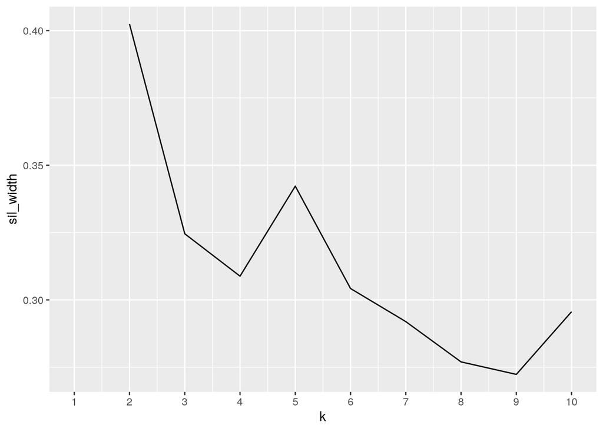

```r
library(cluster)

clust_dat <- pulse %>% dplyr::select(Active, Rest, Wgt, Exercise)

# max sillouette width
sil_width <- vector()
for (i in 2:10) {
    kms <- kmeans(clust_dat, centers = i)
    sil <- silhouette(kms$cluster, dist(clust_dat))
    sil_width[i] <- mean(sil[, 3])
}
ggplot() + geom_line(aes(x = 1:10, y = sil_width)) + scale_x_continuous(name = "k",
    breaks = 1:10)
```

```r
pam <- clust_dat %>% pam(k = 2)
pam
```

```
## Medoids:
##       ID Active Rest Wgt Exercise
## [1,] 210     92   68 135        3
## [2,]  82     84   64 185        3
## Clustering vector:
##   [1] 1 2 2 2 1 2 1 2 2 1 2 1 1 2 1 1 2 2 1 2 1 1 1 1 2 1 2 2 1 1 1 2 2 2 1 2 1
##  [38] 2 1 1 2 1 1 1 1 1 1 2 1 1 2 1 2 2 2 1 2 2 1 1 1 1 2 1 1 1 2 1 1 1 1 2 1 2
##  [75] 2 2 1 1 1 1 2 2 1 1 1 1 1 1 1 1 2 1 1 1 2 2 1 1 2 1
##  [ reached getOption("max.print") -- omitted 132 entries ]
## Objective function:
##    build     swap
## 27.78674 24.74078
##
## Available components:
##  [1] "medoids"    "id.med"     "clustering" "objective"  "isolation"
##  [6] "clusinfo"   "silinfo"    "diss"       "call"       "data"
```

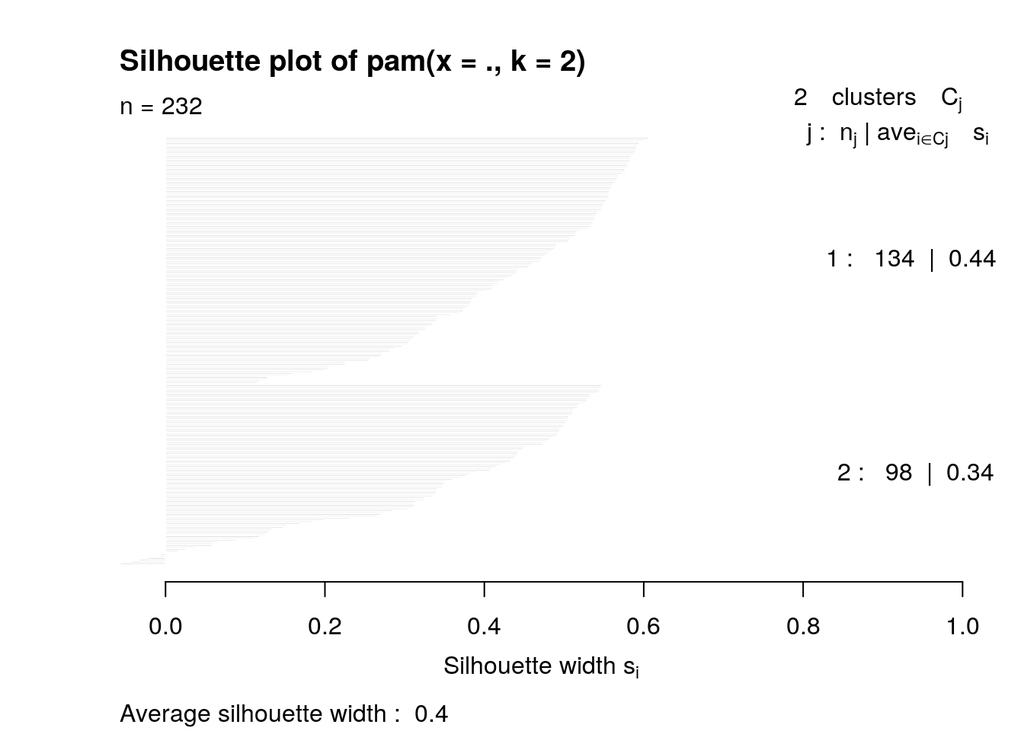

```r
plot(pam, which = 2)
```

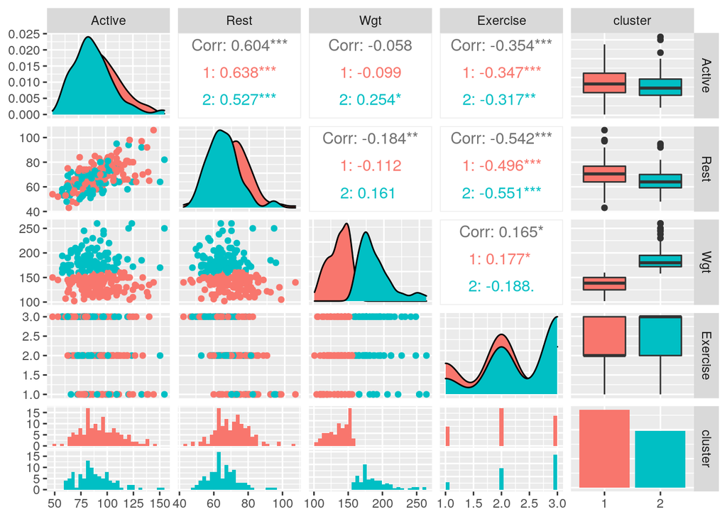

```r
pamclust <- clust_dat %>% mutate(cluster = as.factor(pam$clustering))

# Visualize the clusters by showing all pairwise combinations
# of variables colored by cluster assignment
library(GGally)
ggpairs(pamclust, aes(color = cluster))
```